# Color metrics tutorial (Psych 221)

## Contents

- Examine properties of the CIELAB color metric.
- Load a light source.
- Compute the surface XYZ values
- The XYZ values of the gray surfaces plotted in 3-dimensions
- Convert these values to CIELAB values.
- Plot in 3 dimensions for LAB space.
- Examine the chromaticity coordinates of these gray surfaces.
- Creating and rendering the Lab values
- LAB values in chromaticity space
- Render these XYZ values.
- The linear rgb values
- This is the inverse of the gamma function
- Show examples of LAB varying images
- Create the varyBstar values
- The Delta E_ab value
- Visualize the $\Delta E$differences
- TUTORIAL QUESTIONS
- Calculate CIELAB values for some simple surfaces and lights
- Plot the relationship between linear intensity values and L*
- Render CIELAB values on the screen
- Calculate delta E values in a simple example

**Summary**

- Class: Psych 221/EE 362
- Tutorial: Color metrics
- Author: Wandell
- Initial date: 01.12.98
- Revised: 05.03.99 by Michael Bax
- Checked: Matlab 7, GN, BW, 2006
- Duration: 45 minutes

```matlab
ieInit
```

## Examine properties of the CIELAB color metric.

The CIELAB metric is designed to help predict the similarity between two spatially uniform targets. Let's simulate a set of gray surfaces whose reflectance functions are linearly scaled with respect to one another.

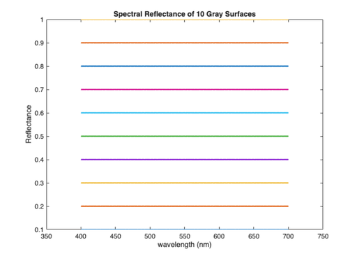

```matlab
wavelength = 400:700;
graySurfaces = ones(length(wavelength),10)*diag((.1:.1:1));

ieNewGraphWin;
plot(wavelength,graySurfaces,'LineWidth',2)
set(gca,'xlim',[350 750]);
xlabel('wavelength (nm)'); ylabel('Reflectance')
title('Spectral Reflectance of 10 Gray Surfaces');
```

## Load a light source.

D65 refers to a light with a color temperature of 6500 deg Kelvin. This is a slightly bluish appearing light source. This light is often used as a model of daylight (blue sky).

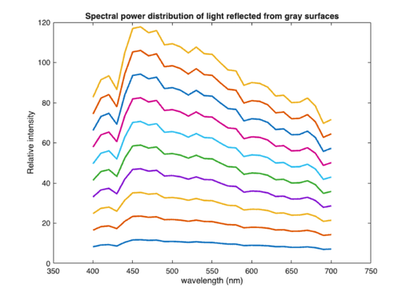

```matlab
lgt = ieReadSpectra('D65',wavelength);

% Illuminate the surfaces with the light source and plot the
% resulting scattered light
graySPD = diag(lgt)*graySurfaces;

ieNewGraphWin;
plot(wavelength,graySPD,'LineWidth',2);
set(gca,'xlim',[350 750]);
xlabel('wavelength (nm)'); ylabel('Relative intensity')
title('Spectral power distribution of light reflected from gray surfaces');
```

## Compute the surface XYZ values

```matlab
% These are the CIE XYZ color matching functions
XYZ = ieReadSpectra('XYZ',wavelength);
% ieNewGraphWin; plot(wavelength,XYZ);
grayXYZ = ieXYZFromEnergy(graySPD',wavelength)';

% Remember:  the Y value of a white surface is always 100, so we
% must scale the results by the Y value of the white surface,
% appropriately.  The second row is Y, and the tenth surface is white.
grayXYZ = grayXYZ * 100 / grayXYZ(2,10)

% To compute the CIELAB values, we will need to use the XYZ values
% of the white surface.  So, let's save them in a special
% variable.
whiteXYZ = grayXYZ(:,10)
```

```
grayXYZ =

  Columns 1 through 7

    9.4912   18.9824   28.4736   37.9648   47.4561   56.9473   66.4385
   10.0000   20.0000   30.0000   40.0000   50.0000   60.0000   70.0000
   10.8563   21.7125   32.5688   43.4250   54.2813   65.1375   75.9938

  Columns 8 through 10

   75.9297   85.4209   94.9121
   80.0000   90.0000  100.0000
   86.8500   97.7063  108.5625


whiteXYZ =

   94.9121
  100.0000
  108.5625
```

Notice that the Y values of these 10 surfaces are linearly spaced. That is because Y is a linear computation from the SPD. The X and Z values are linear, too (not shown).

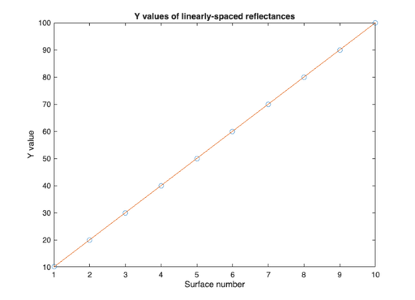

```matlab
ieNewGraphWin;
plot(1:10, grayXYZ(2,:),'o',1:10,grayXYZ(2,:),'-')
xlabel('Surface number'); ylabel('Y value')
title('Y values of linearly-spaced reflectances');
```

## The XYZ values of the gray surfaces plotted in 3-dimensions

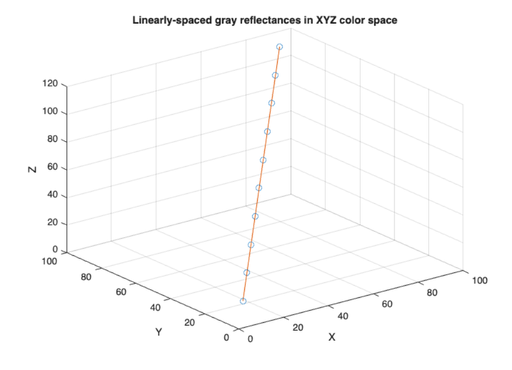

```matlab
ieNewGraphWin;
plot3(grayXYZ(1,:), grayXYZ(2,:), grayXYZ(3,:),'o',...
    grayXYZ(1,:), grayXYZ(2,:), grayXYZ(3,:),'-');
xlabel('X'); ylabel('Y'); zlabel('Z');
title('Linearly-spaced gray reflectances in XYZ color space');
grid on;
```

## Convert these values to CIELAB values.

We use the routine ieXYZ2LAB to convert the CIELAB. Notice that the conversion requires both the XYZ values and the XYZ value of a white point. Take a look at the routine to see what it does by invoking "type ieXYZ2LAB" or "doc ieXYZ2LAB".

```matlab
grayLAB = ieXYZ2LAB(grayXYZ', whiteXYZ' )'
```

```
grayLAB =

  Columns 1 through 7

   37.8424   51.8372   61.6542   69.4695   76.0693   81.8382   86.9969
   -0.0000         0         0   -0.0000         0   -0.0000    0.0000
    0.0000    0.0000   -0.0000    0.0000         0   -0.0000   -0.0000

  Columns 8 through 10

   91.6849   95.9968  100.0000
         0    0.0000         0
    0.0000   -0.0000         0
```

Let's plot the L* values of these gray surfaces. This set of values is not linearly related to the surface reflectance functions. Rather, they are related by a cube root function.

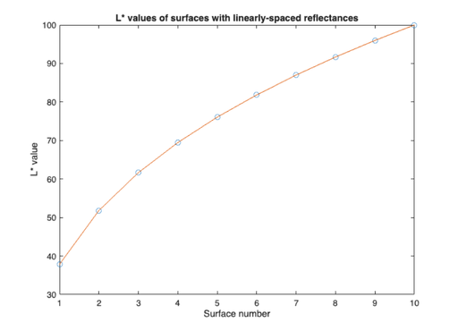

```matlab
ieNewGraphWin;
plot(1:10,grayLAB(1,:),'o',1:10,grayLAB(1,:),'-');
xlabel('Surface number');ylabel('L* value')
title('L* values of surfaces with linearly-spaced reflectances');
```

## Plot in 3 dimensions for LAB space.

Notice that the a* and b* coordinates are zero for the gray series.

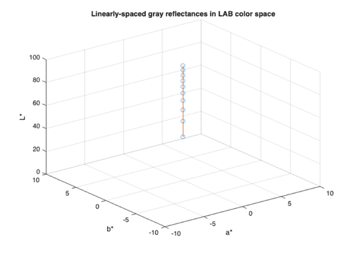

```matlab
ieNewGraphWin;
plot3(grayLAB(2,:), grayLAB(3,:), grayLAB(1,:),'o',...
    grayLAB(2,:), grayLAB(3,:), grayLAB(1,:),'-');
xlabel('a*'); ylabel('b*'); zlabel('L*');
title('Linearly-spaced gray reflectances in LAB color space');
grid on; axis([ -10 10 -10 10 0 100]);
```

## Examine the chromaticity coordinates of these gray surfaces.

Remember that the chromaticity coordinates represent only two of the three dimensions. In this case, the surfaces all share a common "shape" spectral power distribution, and they differ only by a scale factor. So, the surfaces will have the same chromaticity coordinates.

```matlab
grayxy = chromaticity(grayXYZ')'
```

```
grayxy =

  Columns 1 through 7

    0.3128    0.3128    0.3128    0.3128    0.3128    0.3128    0.3128
    0.3295    0.3295    0.3295    0.3295    0.3295    0.3295    0.3295

  Columns 8 through 10

    0.3128    0.3128    0.3128
    0.3295    0.3295    0.3295
```

## Creating and rendering the Lab values

The a* and b* describe aspects of the hue and saturation of the targets For the gray series, the values of a* and b* (the 2nd and third rows of grayLAB) are all near zero. Next, we use the methods we developed in the ColorMatching tutorial to create new Lab values and render them on the screen.

Let's make a list of Lab values that are the same as the gray values, but that systematically vary in their a* values.

```matlab
nChips = size(grayLAB,2);
aRamp = ieScale(1:nChips,-30,30);
varyAstarLAB = zeros([3, nChips]);
varyAstarLAB(1,:) = 70;    % L
varyAstarLAB(2,:) = aRamp; % A = linear ramp
varyAstarLAB(3,:) = 0;
varyAstarLAB
```

```
varyAstarLAB =

  Columns 1 through 7

   70.0000   70.0000   70.0000   70.0000   70.0000   70.0000   70.0000
  -30.0000  -23.3333  -16.6667  -10.0000   -3.3333    3.3333   10.0000
         0         0         0         0         0         0         0

  Columns 8 through 10

   70.0000   70.0000   70.0000
   16.6667   23.3333   30.0000
         0         0         0
```

To see what these Lab values look like, we will (a) convert the Lab values into XYZ values, (b) guess about your screen primary spectral power distributions and gamma to render these XYZ values. The techniques we use here are the same as in the ColorMatching.m tutorial.

First, use this function to invert the LAB values to XYZ values. Notice that we need to know the white point, whiteXYZ.

```matlab
varyXYZ = ieLAB2XYZ(varyAstarLAB',whiteXYZ)'
```

```
varyXYZ =

  Columns 1 through 7

   30.0254   31.8227   33.6904   35.6297   37.6421   39.7289   41.8914
   40.7494   40.7494   40.7494   40.7494   40.7494   40.7494   40.7494
   44.2386   44.2386   44.2386   44.2386   44.2386   44.2386   44.2386

  Columns 8 through 10

   44.1310   46.4490   48.8468
   40.7494   40.7494   40.7494
   44.2386   44.2386   44.2386
```

Stop for just a moment to see how varying the value of a* changes the chromaticity values. Using the XYZ values, we can calculate the chromaticity values. Notice that as we vary a* the chromaticity values move along a simple path.

```matlab
varyxy = chromaticity(varyXYZ')';
```

## LAB values in chromaticity space

```
whitexy =

    0.3128
    0.3295
```

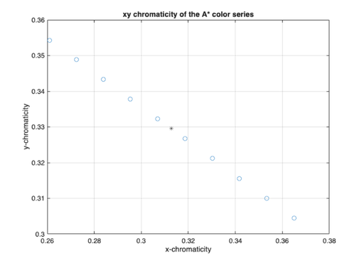

```matlab
ieNewGraphWin;
plot(varyxy(1,:),varyxy(2,:),'o'); hold on
xlabel('x-chromaticity'),ylabel('y-chromaticity')
title('xy chromaticity of the A* color series');
grid on;

% Let's see where the chromaticity point of white is.
whitexy = chromaticity(whiteXYZ')'
hold on; plot(whitexy(1),whitexy(2),'k*'); hold off
```

## Render these XYZ values.

We must load up some calibration information about your monitor. Because I have no idea what monitor you are using -- this is a general problem for the industry -- I am going to just make a guess and use a standard set of monitor values.

```matlab
d = displayCreate('LCD-Apple','wave',wavelength);

% Now, compute the transformations from XYZ to linear rgb and
% back for this monitor
rgb2xyz = displayGet(d,'rgb2xyz');  % Display primary spectral power distribution
xyz2rgb = inv(rgb2xyz);
```

## The linear rgb values

The LAB values we have created can be rendered on a display. We convert the LAB -> XYZ -> RGB. Because of the white point, there is a scalar in the calculation corresponding to the intensity of the assumed light source (white point). Because white is the maximum value, let's scale the color map entries so that the linear rgb values for white are all within the display range (i.e., all the RGB have a value between 0 and 1.0).

```matlab
% This is the RGB of the white point.  We use the max to scale the other
% RGB values.
whiteRGB = (xyz2rgb*whiteXYZ)'
whiteMax = max(whiteRGB)

varyRGB = (xyz2rgb*varyXYZ);
varyRGB = varyRGB/whiteMax;

% We must account for the gamma function of the display, which relates the
% RGB frame buffer values to the linear intensities of the RGB primaries.
invGamTable = displayGet(d,'inverse gamma',1000);
relativeIntensity = (1:length(invGamTable))/length(invGamTable);
```

```
whiteRGB =

    1.9997    0.1025    0.6135


whiteMax =

    1.9997
```

## This is the inverse of the gamma function

The gamma function describes how the primary intensity (y-axis) changes with the digital value in the frame buffer (x-axis). The inverse gamma describes which digital value (y-axis) we should select to achieve a desired primary intensity (between 0 and 1).

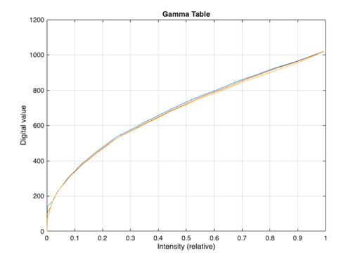

```matlab
ieNewGraphWin;
plot(relativeIntensity,invGamTable)
xlabel('Intensity (relative)'); ylabel('Digital value')
title('Gamma Table');
grid on
```

## Show examples of LAB varying images

We don't know what display you are using. The best we can do is create these images for a relatively common display and show them. There are some simple tools for creating images on a standard display (sRGB). Here is the sequence of calculations.

```
varyXYZ =

  Columns 1 through 7

   30.0254   31.8227   33.6904   35.6297   37.6421   39.7289   41.8914
   40.7494   40.7494   40.7494   40.7494   40.7494   40.7494   40.7494
   44.2386   44.2386   44.2386   44.2386   44.2386   44.2386   44.2386

  Columns 8 through 10

   44.1310   46.4490   48.8468
   40.7494   40.7494   40.7494
   44.2386   44.2386   44.2386


fbRGB(:,:,1) =

    0.5921
    0.7030
    0.7983
    0.8835
    0.9617
    1.0000
    1.0000
    1.0000
    1.0000
    1.0000


fbRGB(:,:,2) =

    1.0000
    1.0000
    1.0000
    1.0000
    1.0000
    0.9895
    0.9662
    0.9413
    0.9145
    0.8857


fbRGB(:,:,3) =

    0.9931
    0.9942
    0.9954
    0.9965
    0.9977
    0.9990
    1.0000
    1.0000
    1.0000
    1.0000
```

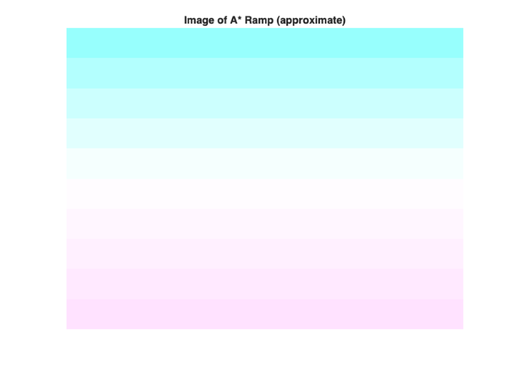

```matlab
% Convert the LAB values into the varyXYZ values
varyXYZ = ieLAB2XYZ(varyAstarLAB',whiteXYZ)'

% Convert the XYZ values into standard display RGB values (sRGB)
fbRGB = xyz2srgb(XW2RGBFormat(varyXYZ',nChips,1))

% Here is the image
ieNewGraphWin;
image(fbRGB)
title('Image of A* Ramp (approximate)');
axis off
```

## Create the varyBstar values

Let's make a similar picture as we vary the b* dimension. Because we have various bits of information loaded up already, we can compute a little more quickly.

```
varyXYZ =

  Columns 1 through 7

   38.6761   38.6761   38.6761   38.6761   38.6761   38.6761   38.6761
   40.7494   40.7494   40.7494   40.7494   40.7494   40.7494   40.7494
   76.8896   68.5822   60.8959   53.8064   47.2897   41.3216   35.8781

  Columns 8 through 10

   38.6761   38.6761   38.6761
   40.7494   40.7494   40.7494
   30.9349   26.4680   22.4532


fbRGB(:,:,1) =

    0.7965
    0.8541
    0.9031
    0.9454
    0.9822
    1.0000
    1.0000
    1.0000
    1.0000
    1.0000


fbRGB(:,:,2) =

    1.0000
    1.0000
    1.0000
    1.0000
    1.0000
    0.9993
    0.9968
    0.9946
    0.9925
    0.9907


fbRGB(:,:,3) =

    1.0000
    1.0000
    1.0000
    1.0000
    1.0000
    0.9643
    0.8959
    0.8273
    0.7582
    0.6881
```

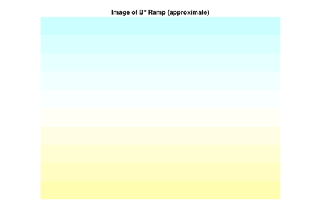

```matlab
varyBstar(1,:) = 70*ones(1,nChips); % L
varyBstar(2,:) = zeros(1,nChips);   % A*
varyBstar(3,:) = aRamp;             % B*

% Convert Lab to XYZ values
varyXYZ = ieLAB2XYZ(varyBstar',whiteXYZ)'
fbRGB = xyz2srgb(XW2RGBFormat(varyXYZ',nChips,1))
image(fbRGB)
title('Image of B* Ramp (approximate)');
axis off

% By the way: do you see a visual illusion in these images?  The regions
% near the edges (the stimulus is constant) are called colored Mach Bands.
```

## The Delta E_ab value

A central purpose in creating the CIELAB Metric is to be able to measure the perceived difference between pairs of lights (when the lights are not too dissimilar). In this section we create a series of colors that are 5 units apart.

We add this difference into all of the gray series. Notice that we add the same difference to every one of the gray chips.

```matlab
deltaXYZ = zeros(size(grayXYZ));
deltaXYZ(2,:) = (whiteXYZ(2)/20);
deltaXYZ
```

```
deltaXYZ =

     0     0     0     0     0     0     0     0     0     0
     5     5     5     5     5     5     5     5     5     5
     0     0     0     0     0     0     0     0     0     0
```

Measure the Lab differences between the original grayXYZ and these values with the constant difference added into each gray chip.

```matlab
lab1 = ieXYZ2LAB( grayXYZ.', whiteXYZ.' ).';
lab2 = ieXYZ2LAB( ( grayXYZ + deltaXYZ ).', whiteXYZ.' ).';
diffLAB = lab1 - lab2;
```

To see the LAB values in three space for the grayXYZ series and the one separated by deltaXYZ, use this code. It shows the series of LAB values of the two different sets, separated by a constant difference.

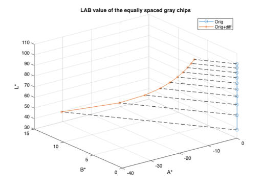

```matlab
ieNewGraphWin; plot3(lab1(2,:),lab1(3,:),lab1(1,:),'-o',...
    lab2(2,:),lab2(3,:),lab2(1,:),'-*')

for ii=1:size(lab1,2)
    hold on;
    plot3([lab1(2,ii); lab2(2,ii)], ...   % A;egmoqs
        [lab1(3,ii); lab2(3,ii)], ... % B
        [lab1(1,ii); lab2(1,ii)], 'k--'); % L
end
hold off; grid on;
zlabel('L*'), xlabel('A*'); ylabel('B*')
title('LAB value of the equally spaced gray chips')
legend('Orig', 'Orig+diff', 'Location','NorthEast');
```

## Visualize the $\Delta E$differences

```matlab
nChips = size(grayXYZ,2)
dEab = zeros(1,nChips);
for ii=1:nChips
  dEab(ii) = norm( diffLAB(:,ii));
end
```

```
nChips =

    10
```

Recall that the deltaXYZ is the same at all these levels. But, the delta Eab varies because we are more sensitive at lower intensity levels than at high one. So, the delta Eab value for at the dark chips is much larger than the delta Eab value for the light chips. (Note that this is a simplified version of the information in the 3D plot above.)

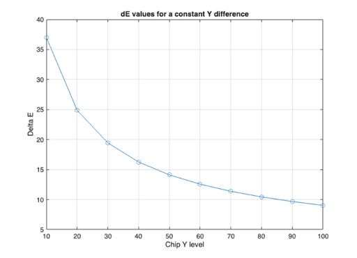

```matlab
ieNewGraphWin;
plot(grayXYZ(2,:),dEab,'-o')
xlabel('Chip Y level'); ylabel('Delta E');
title('dE values for a constant Y difference')
grid on
```

## TUTORIAL QUESTIONS

Question 1: Suppose you had to choose a set of gray reflectances that are equally spaced in LAB coordinates. How would you choose the reflectance levels of the gray series? Explain this qualitatively, based on the CIELAB metric formula (See Color Appearance Lecture Notes). Question 2: Is visual sensitivity greater for distinguishing the mean reflectance of dark surfaces or light surfaces? Justify your answer using the CIELAB formula. (See Color Appearance Lecture Notes). Question 3: Suppose we measure the XYZ values of each of a pair of lights. According to the CIELAB metric, what other values must we measure before we can predict the discriminability of these lights? What basic processes in the visual system do these other values represent? Question 4: Set the white point to whiteXYZ = [100,100,100]; Consider the point pXYZ = [50,100,100]; What is the delta E spacing between pXYZ and another point that differs by 5 units in each principal direction (e.g., [55,100,100])? Question 5: USING CIELAB TO COMPARE IMAGES Define the colors

yellowRGB = [1.0 1.0 0.0]

blueRGB = [0.25 0.625 1.0]

greenRGB = [0.625, 0.8125, 0.5]

a) Compute the XYZ values for these colors when displayed on our standard (linear) monitor (i.e., ignore gamma correction).

b) Compute the LAB values for these colors for a white point of whiteXYZ = [95 100 108]

Change the white point to whiteXYZ = [108 100 95] and compute the LAB values again. Does the white point have a big effect? Does changing the white point have the same effect on L, a* and b*?

c) Using the original white point whiteXYZ = [95 100 108], compute the delta E difference between each combination of the three colors (yellowRGB ...). Based on these results, which pair of colors is most dissimilar?

d) Use the following code to generate three images imYB1, imYB2, and imG. (Do not submit these images, but you may describe what you see.)

```
       imw = 128;
       imYB1 = repmat(reshape(yellowRGB,1,1,3), [256 imw]);
       ss = 1;
       for ii = 1:ss
           imYB1(ii:(2*ss):256, :, :) = ...
               repmat(reshape(blueRGB,1,1,3), [256/ss/2 imw]);
       end
       imYB2 = repmat(reshape(yellowRGB,1,1,3), [256 imw]);
       ss = 16;
       for ii = 1:ss
           imYB2(ii:(2*ss):256, :, :) = ...
               repmat(reshape(blueRGB,1,1,3), [256/ss/2 imw]);
       end
```

```
       imG = repmat(reshape(greenRGB,1,1,3), [256, imw]);
```

Measure the delta E difference between imYB1 and imG, and the difference between imYB2 and imG, and compare these values. Define the difference between two images to be the average delta E difference across all pixels. (Use the white point whiteXYZ = [95 100 108]).

Hints: - You may find the command imdata = reshape(im, size(im,1)*size(im,2),3); useful for transforming an m x n x 3 image into an (m*n) x 3 matrix of pixels.

- You can use ieXYZ2LAB to convert XYZ data to LAB data in bulk. ieXYZ2LAB may take an nx3 matrix of XYZ values to LAB values (where each row is an XYZ color vector).

e) View the images side by side and compare them. Notice that the average delta E of (imYB1 vs imG) and of (imYB2 vs imG) do not agree with the appearance similarity. Explain why you think the appearance and delta E values diverge. Suggest a way to improve the CIELAB metric so it more accurately reflects the perceived difference.

[Published with MATLAB® R2025b](https://www.mathworks.com/products/matlab/)